# R Notebook for Cochrane systematic review on pNAAT for SARS-CoV-2

## 5.6 Summary all subgroups

```r
psum4 <-psum3 %>% rename (Subgroup= pool_size_gp)
naatsum4 <-naatsum3 %>% rename (Subgroup= naat)
sxsum4 <-sxsum3 %>% rename (Subgroup= symptoms)
sampsum4 <-sampsum3 %>% rename (Subgroup= sample)
ptypesum4 <-ptypesum3 %>% rename (Subgroup= pool_type)
subgp <- rbind(psum4, naatsum4, sxsum4, sampsum4, ptypesum4)
subgpgt <-gt(subgp) %>%
  tab_row_group("Pool type", rows = 15:18, id = "pooltype") %>%
tab_row_group("Sample type", rows = 13:14, id = "sample") %>%
  tab_row_group("Symptom status", rows = 10:12, id = "symptoms") %>%
  tab_row_group("NAAT type", rows = 6:9, id = "naat")%>%
   tab_row_group("Pool size", rows = 1:5, id = "pooln")  %>%
 fmt_number(columns= c("estimate_Sensitivity", "lower 99% CI_Sensitivity", "upper 99% CI_Sensitivity","estimate_Specificity", "lower 99% CI_Specificity", "upper 99% CI_Specificity"), decimals=3) %>%
   cols_merge(columns = c("lower 99% CI_Sensitivity","upper 99% CI_Sensitivity"),
    pattern = "{1}&mdash;{2}")  %>%
   cols_merge(columns = c("lower 99% CI_Specificity","upper 99% CI_Specificity"),
    pattern = "{1}&mdash;{2}") %>%
  cols_move(
    columns = "estimate_Specificity",
    after = "lower 99% CI_Sensitivity"
  ) %>%
  cols_label(
    estimate_Sensitivity = "Est.",
    estimate_Specificity = "Est.",
    "lower 99% CI_Sensitivity" = "99% CI",
    "lower 99% CI_Specificity" = "99% CI") %>%
  tab_spanner(
    label = "Sensitivity",
    columns = c(estimate_Sensitivity,"lower 99% CI_Sensitivity")) %>%
  tab_spanner(
    label = "Specificity",
    columns = c(estimate_Specificity,"lower 99% CI_Specificity")) %>%
  cols_align ("left", columns=Subgroup)
subgpgt
```

[output not shown]

# 6. Meta-regression exploring heterogeneity

Meta-regressions were conducted for:

1. Univariate binomial random-effects model:
- Outcome:Sensitivity
- Variance assessed within (level 1) and between (level 2) test evaluations.
2. Bivariate binomial partial random-effects model
- Outcome: Sensitivity and specificity
- Variance assessed within (level 1) and between (level 2) test evaluations.
- Random effects considered for sensitivity, but specificity modelled by fixed effects only.
- A block-wise backwards-elimination approach in which covariates were entered in groups (blocks) defined a priori on the basis of theoretical importance:
  - Block 1 (matchiing sub-groups): naat, symptoms, pool size, sample type, pooling method, proportion weak positives
  - Block 2: proportion pools containing >1 positive sample, quality group, limit of detection (lod), positivity rate
  - Block 3: modified protocol, modified interpretation, regulatory status, number of targets, number of targets amplified for positive result, target genes, storage of samples, reference standard same time, reference standard same sample, reference standard same assay.
- After entering the first block, we removed covariates, starting with those non-significantly associated with sensitivity and highly colinear with other variables. We reviewed BIC and likelihood-ratio after removing variables to determine if the covariate could be removed without compromising model fit. This continued until only covariates that were significant (at a=0.05) and improved model fit (according to lrtest) were retained.
- This process was applied for second and third rank blocks.

## 6.1 Exploring relationships between covariates and sensitivity

Before meta-regression we examine nature of relationships between independent variables (covariates) and outcomes (sensitivity, specificity):

### 6.1.1 Associations of continuous covariates and outcomes

```r
y1semp<- y1semp %>% mutate(sensitivity = t_p/disease_p)
y1sempexp<- y1semp %>% mutate(logit = log(sensitivity/(1-sensitivity)))
y1semp_explore <- y1sempexp %>% dplyr::select(
  weak_posfold, multiposfold,positivity_ratefold, log2p, log2lod,logit,sensitivity, modified_interpret)
predictors <- colnames(y1semp_explore)


y1semp_explore1 <-y1semp_explore %>%
  gather(key = "predictors", value = "predictor.value",
         -c(logit,sensitivity, weak_posfold, multiposfold, positivity_ratefold,
            modified_interpret))

plot1 <- ggplot(y1semp_explore1, aes(predictor.value, logit))+
  geom_point(size = 0.3, alpha = 0.5) +
  geom_smooth(method = "loess", size = 0.5) +
  geom_smooth(method = "lm", color="darkred", linetype="dashed", size = 0.5, se=FALSE) +
  facet_wrap(~predictors, scales = "free_x")+
  labs(y = "Logit Sensitivity", x = "Log 2 of Limit of detection (lod), Pool size (p), Modified cut-off+5")

y1semp_explore2 <-y1semp_explore %>%
  gather(key = "predictors", value = "predictor.value",
         -c(logit,sensitivity, log2p, log2lod))

plot2 <- ggplot(y1semp_explore2, aes(predictor.value, logit))+
  geom_point(size = 0.3, alpha = 0.5) +
  geom_smooth(method = "loess", size = 0.5) +
  geom_smooth(method = "lm", color="darkred", linetype="dashed", size = 0.5, se=FALSE) +
  facet_wrap(~predictors, scales = "free_x")+
  labs(y = "Logit Sensitivity", x = "Folded root of x")

plot1
plot2
```

Observations:

### 6.1.2 Correlations between continuous covariates

```r
y1sempexp2 <- as_tibble(y1sempexp)
explanatory <-y1sempexp2 %>% dplyr::select(log2p,multiposfold,log2lod,weak_posfold, positivity_ratefold)
write_csv(explanatory, "exp.csv")
cont <- read_csv("exp.csv")
GGally::ggpairs(cont, columns=1:5)
```

### 6.1.3 Homogeneity of variance between factor levels

```r
lt1<- leveneTest(residuals(ysemp2) ~ y1semp$naat)
lt2<- leveneTest(residuals(ysemp2) ~ y1semp$sample)
lt3<- leveneTest(residuals(ysemp2) ~ y1semp$modified_protocol)
lt4<- leveneTest(residuals(ysemp2) ~ y1semp$reg)
lt<- rbind(lt1[1,1:3],lt2[1,1:3],lt3[1,1:3],lt4[1,1:3])
covariate <- c("NAAT type", "Sample type", "Modified protocol", "Regulatory authorisation")
lt <- cbind(covariate,lt)
lt
```

```r
y1sempexp<- as.tibble(y1sempexp)
y1sempexp$sample <- dplyr::recode_factor (y1sempexp$sample, "Upper respiratory tract swab" = "URT Swab")

cvarp1<- ggplot(y1sempexp, aes(x=naat,y=sensitivity, colour=naat)) + geom_boxplot()+
geom_jitter(alpha=0.2)+ coord_flip() + theme(legend.position="none")+scale_y_continuous(
  breaks=seq(0,1,0.1), limits=c(0.5,1))
cvarp2<- ggplot(y1sempexp, aes(x=naat,y=logit, colour=naat)) + geom_boxplot()+
geom_jitter(alpha=0.2)+ coord_flip() + theme(legend.position="none")
cvarp3<- ggplot(y1sempexp, aes(x=sample ,y=sensitivity, colour=sample))+ geom_boxplot ()+
geom_jitter(alpha=0.2) + coord_flip() + theme(legend.position="none")
cvarp4<- ggplot(y1sempexp, aes(x=sample ,y=logit, colour=sample))+ geom_boxplot ()+
geom_jitter(alpha=0.2) + coord_flip() + theme(legend.position="none")
cvarp5<- ggplot(y1sempexp, aes(x=modified_protocol,y=sensitivity, colour=modified_protocol)) + geom_boxplot() + theme(legend.position="none")+ geom_jitter(alpha=0.2) + coord_flip()
cvarp6<- ggplot(y1sempexp, aes(x=modified_protocol,y=logit, colour=modified_protocol)) + geom_boxplot() + theme(legend.position="none")+ geom_jitter(alpha=0.2) + coord_flip()
cvarp7<- ggplot(y1sempexp, aes(x=reg,y=sensitivity, colour=reg)) + geom_boxplot() + theme(legend.position="none")+ geom_jitter(alpha=0.2) + coord_flip()
cvarp8<- ggplot(y1sempexp, aes(x=reg, y=logit, colour=reg)) + theme(legend.position="none")+ geom_jitter(alpha=0.2) + coord_flip()
a<- ggarrange(cvarp1,cvarp2)
b<- ggarrange(cvarp3,cvarp4)
c<- ggarrange(cvarp5,cvarp6)
d<- ggarrange(cvarp7,cvarp8)
ggarrange(a,b,c,d, nrow = 4)
```

## 6.2 Models with Random effects at test evaluation level

### 6.2.1 Block 1 model

Variables considered in block 1 reflected those selected a priori to be most important * log2 of pool size * % weak positives * NAAT type * Symptom status * Sample type * Pooling method

#### Block 1 Saturated model

Adding all variables

```r
# Saturated Block 1 model
ysemp4 <- glmer (formula= cbind(true,n-true)~ 1+weak_posfold+naat+symptoms+log2p+sample+pool_type+(1|testeval),
                 data = y1semp,family=binomial, nAGQ=1,verbose=0,
                 control=glmerControl(optimizer="bobyqa",optCtrl=list
                                      (maxfun=2e5)))
ysemp4_sum <- summary(ysemp4)
ysemp4_sum
```

#### Block 1 Best Fit model

```r
ysemp5 <- glmer (formula= cbind(true,n-true)~ 1+weak_posfold+naat+log2p+pool_type+(1|testeval),
                 data = y1semp,family=binomial, nAGQ=1,verbose=0,
                 control=glmerControl(optimizer="bobyqa",optCtrl=list
                                      (maxfun=2e5)))
ysemp5_sum <- summary(ysemp5)
ysemp5_sum
lrtest(ysemp4,ysemp5)
```

### 6.2.2 Block 2 model

#### Block 2 saturated model

```r
ysemp6 <- glmer (formula= cbind(true,n-true)~ 1+weak_posfold+naat+log2p+pool_type+multiposfold+quality+log2lod+positivity_ratefold+ (1|testeval),
                 data = y1semp,family=binomial, nAGQ=1,verbose=0,
                 control=glmerControl(optimizer="bobyqa",optCtrl=list
                                      (maxfun=2e5)))
ysemp6_sum <- summary(ysemp6)
ysemp6_sum
```

#### Block 2 Best Fit model

```r
ysemp7 <- glmer (formula= cbind(true,n-true)~ 1+weak_posfold+log2p+naat+pool_type+
                   (1|testeval),
                 data = y1semp,family=binomial, nAGQ=1,verbose=0,
                 control=glmerControl(optimizer="bobyqa",optCtrl=list
                                      (maxfun=2e5)))
ysemp7_sum <- summary(ysemp7)
ysemp7_sum
lrtest(ysemp6,ysemp7)
```

### 6.2.3 Block 3 model

Variables considered:

- modified protocol,
- modified interpretation,
- regulatory status
- number of targets,
- number of targets amplified for positive result,
- target genes,
- storage of samples,
- reference standard same cut-off
- reference standard same assay.

#### Block 3 staturated model

```r
ysemp8 <- glmer (formula= cbind(true,n-true)~1+weak_posfold+naat+log2p
                 +sample+modified_protocol+modified_interpret+reg+storage+refst_same_cutoff+refstd_same_assay+
                   (1|testeval),
                 data = y1semp,family=binomial, nAGQ=1,verbose=0,
                 control=glmerControl(optimizer="bobyqa",optCtrl=list
                                      (maxfun=2e5)))
ysemp8_sum <- summary(ysemp8)
ysemp8_sum
```

#### Block 3 (final) best fit model

```r
ysemp9 <- glmer (formula= cbind(true,n-true)~1+naat+log2p
                 +sample+modified_protocol+weak_posfold+modified_interpret+reg+
                   (1|testeval),
                 data = y1semp,family=binomial, nAGQ=1,verbose=0,
                 control=glmerControl(optimizer="bobyqa",optCtrl=list
                                      (maxfun=2e5)))
ysemp9_sum <- summary(ysemp9)
ysemp9_sum
```

```
Generalized linear mixed model fit by maximum likelihood (Laplace
  Approximation) [glmerMod]
 Family: binomial  ( logit )
Formula:
cbind(true, n - true) ~ 1 + naat + log2p + sample + modified_protocol +
    weak_posfold + modified_interpret + reg + (1 | testeval)
   Data: y1semp
Control:
glmerControl(optimizer = "bobyqa", optCtrl = list(maxfun = 2e+05))

     AIC      BIC   logLik deviance df.resid
   310.1    332.4   -145.1    290.1       59

Scaled residuals:
     Min       1Q   Median       3Q      Max
-1.35660 -0.38243 -0.06894  0.59972  1.69882

Random effects:
 Groups   Name        Variance Std.Dev.
 testeval (Intercept) 0.5743   0.7578
Number of obs: 69, groups:  testeval, 69

Fixed effects:
                   Estimate Std. Error z value Pr(>|z|)
(Intercept)         1.62275    0.37064   4.378 1.20e-05 ***
naatDigital RT-PCR  3.11592    0.91212   3.416 0.000635 ***
naatTMA            -1.49560    0.46318  -3.229 0.001242 **
log2p              -0.76683    0.18869  -4.064 4.82e-05 ***
sampleSaliva       -0.88505    0.40526  -2.184 0.028972 *
modified_protocolT  1.22255    0.39640   3.084 0.002041 **
weak_posfold       -2.61700    0.48265  -5.422 5.89e-08 ***
modified_interpret  0.20222    0.07259   2.786 0.005342 **
regTRUE             1.18693    0.41104   2.888 0.003881 **
---
Signif. codes:  0 ‘***’ 0.001 ‘**’ 0.01 ‘*’ 0.05 ‘.’ 0.1 ‘ ’ 1

Correlation of Fixed Effects:
            (Intr) nDRT-P natTMA log2p  smplSl mdfd_T wk_psf mdfd_n
ntDgtRT-PCR -0.464
naatTMA     -0.032 -0.036
log2p        0.194 -0.372  0.142
sampleSaliv -0.081  0.041  0.205  0.015
mdfd_prtclT -0.019  0.106  0.046 -0.276 -0.362
weak_posfld -0.176 -0.017  0.236  0.099  0.204 -0.248
mdfd_ntrprt -0.110  0.185  0.041 -0.149  0.236  0.167 -0.298
regTRUE     -0.872  0.417 -0.204 -0.182 -0.104 -0.099  0.035  0.071
```

```r
lrtest(ysemp8,ysemp9)
```

```
Likelihood ratio test

Model 1: cbind(true, n - true) ~ 1 + weak_posfold + naat + log2p + sample +
    modified_protocol + modified_interpret + reg + storage +
    refst_same_cutoff + refstd_same_assay + (1 | testeval)
Model 2: cbind(true, n - true) ~ 1 + naat + log2p + sample + modified_protocol +
    weak_posfold + modified_interpret + reg + (1 | testeval)
  #Df  LogLik Df  Chisq Pr(>Chisq)
1  15 -137.64
2  10 -145.05 -5 14.816    0.01118 *
---
Signif. codes:  0 ‘***’ 0.001 ‘**’ 0.01 ‘*’ 0.05 ‘.’ 0.1 ‘ ’ 1
```

### 6.2.4 Diagnostics on final block 3 model

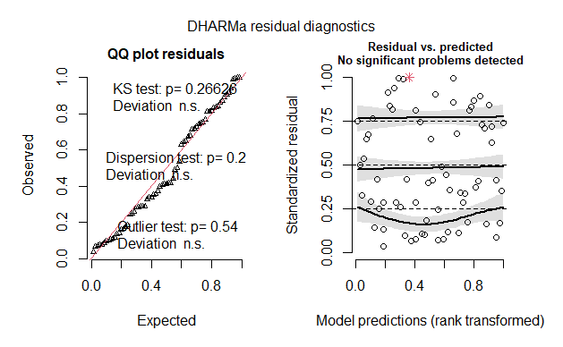

```r
# Obtain residuals
simulationOutput <- simulateResiduals(ysemp9, plot = T)
```

```
    DHARMa nonparametric dispersion test via sd of residuals fitted
    vs. simulated

data:  simulationOutput
dispersion = 1.0744, p-value = 0.2
alternative hypothesis: two.sided
```

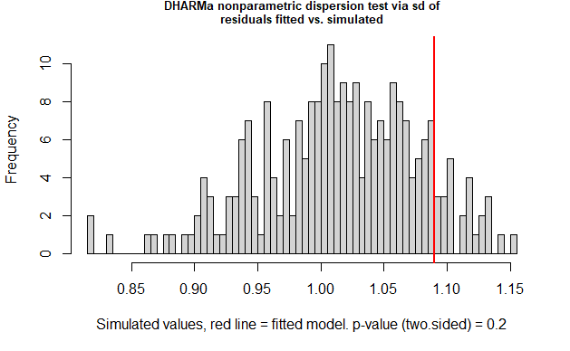

```r
# Check for under/over dispersion
testDispersion(simulationOutput)
```

```
$uniformity
$uniformity$details
catPred: FALSE

    One-sample Kolmogorov-Smirnov test

data:  dd[x, ]
D = 0.26631, p-value = 0.4678
alternative hypothesis: two-sided

--------------------------------------------------------
catPred: TRUE

    One-sample Kolmogorov-Smirnov test

data:  dd[x, ]
D = 0.11552, p-value = 0.3714
alternative hypothesis: two-sided


$uniformity$p.value
[1] 0.4678244 0.3713927

$uniformity$p.value.cor
[1] 0.7427855 0.7427855


$homogeneity
Levene's Test for Homogeneity of Variance (center = median)
      Df F value Pr(>F)
group  1  0.0219 0.8829
      67
```

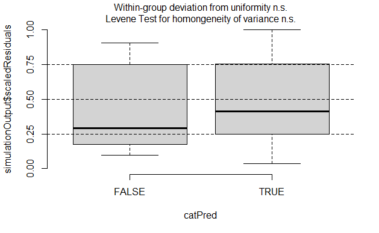

```r
# Check of residuals against predictors
testCategorical(simulationOutput, catPred = y1semp$reg)
```

```
$uniformity
$uniformity$details
catPred: RT-PCR

    One-sample Kolmogorov-Smirnov test

data:  dd[x, ]
D = 0.10739, p-value = 0.4514
alternative hypothesis: two-sided

--------------------------------------------------------
catPred: Digital RT-PCR

    One-sample Kolmogorov-Smirnov test

data:  dd[x, ]
D = 0.49375, p-value = 0.3481
alternative hypothesis: two-sided

--------------------------------------------------------
catPred: TMA

    One-sample Kolmogorov-Smirnov test

data:  dd[x, ]
D = 0.28367, p-value = 0.7273
alternative hypothesis: two-sided


$uniformity$p.value
[1] 0.4513742 0.3480814 0.7273108

$uniformity$p.value.cor
[1] 1 1 1


$homogeneity
Levene's Test for Homogeneity of Variance (center = median)
      Df F value Pr(>F)
group  2  1.6349 0.2028
      66
```

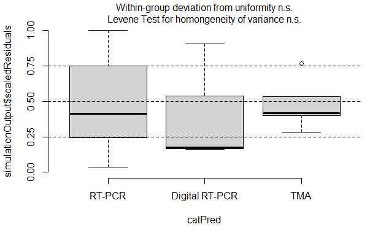

```r
testCategorical(simulationOutput, catPred = y1semp$naat)
```

```
$uniformity
$uniformity$details
catPred: F

    One-sample Kolmogorov-Smirnov test

data:  dd[x, ]
D = 0.10071, p-value = 0.608
alternative hypothesis: two-sided

--------------------------------------------------------
catPred: T

    One-sample Kolmogorov-Smirnov test

data:  dd[x, ]
D = 0.18903, p-value = 0.5923
alternative hypothesis: two-sided


$uniformity$p.value
[1] 0.6079541 0.5923247

$uniformity$p.value.cor
[1] 1 1


$homogeneity
Levene's Test for Homogeneity of Variance (center = median)
      Df F value Pr(>F)
group  1   2.046 0.1573
      67
```

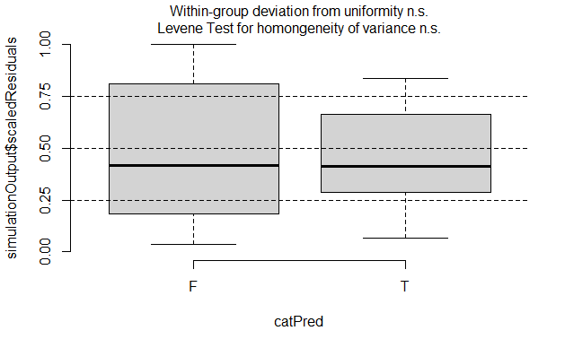

```r
testCategorical(simulationOutput, catPred = y1semp$modified_protocol)
```

```
    Test for location of quantiles via qgam

data:  simulationOutput
p-value = 0.0509
alternative hypothesis: both
```

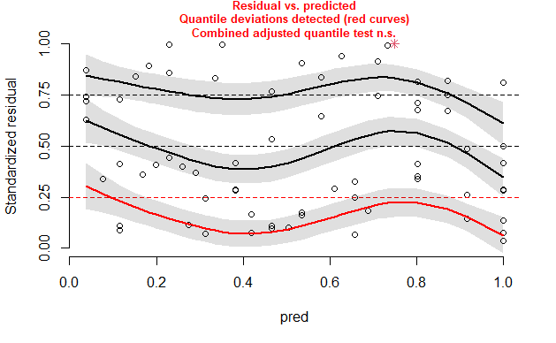

```r
# Check for homogeneity of variance over range of continuous variables
testQuantiles(simulationOutput, predictor=y1semp$weak_posfold, plot=T)
```

```
    Test for location of quantiles via qgam

data:  simulationOutput
p-value = 0.5396
alternative hypothesis: both
```

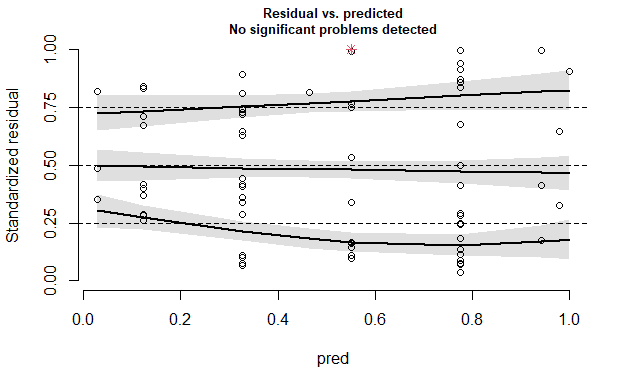

```r
testQuantiles(simulationOutput, predictor=y1semp$log2p, plot=T)
```

```
    Test for location of quantiles via qgam

data:  simulationOutput
p-value = 0.6126
alternative hypothesis: both
```

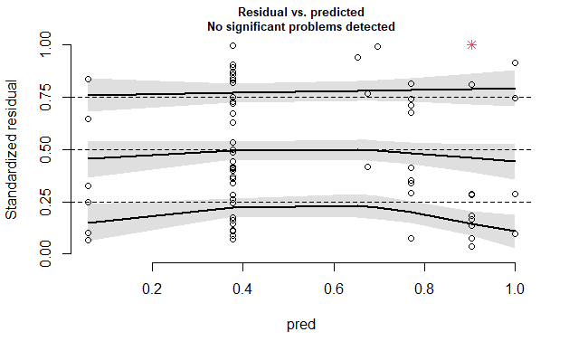

```r
testQuantiles(simulationOutput, predictor=y1semp$modified_interpret, plot=T)
```

```r
# Check for homogeneity of variance between categories of factors
leveneTest(residuals(ysemp9) ~ y1semp$naat)
```

```
Levene's Test for Homogeneity of Variance (center = median)
      Df F value Pr(>F)
group  2   2.166 0.1227
      66
```

```r
leveneTest(residuals(ysemp9) ~ y1semp$sample)
```

```
Levene's Test for Homogeneity of Variance (center = median)
      Df F value Pr(>F)
group  1   0.623 0.4327
      67
```

```r
leveneTest(residuals(ysemp9) ~ y1semp$modified_protocol)
```

```
Levene's Test for Homogeneity of Variance (center = median)
      Df F value Pr(>F)
group  1  0.2125 0.6463
      67
```

```r
leveneTest(residuals(ysemp9) ~ y1semp$reg)
```

```
Levene's Test for Homogeneity of Variance (center = median)
      Df F value Pr(>F)
group  1  0.8987 0.3465
      67
```

```r
# Check for multi-colinearity by VIF
car::vif(ysemp9)
```

```
                       GVIF Df GVIF^(1/(2*Df))
naat               1.680970  2        1.138649
log2p              1.295425  1        1.138167
sample             1.489119  1        1.220295
modified_protocol  1.479894  1        1.216509
weak_posfold       1.304749  1        1.142256
modified_interpret 1.343626  1        1.159149
reg                1.364195  1        1.167988
```

### 6.2.5 A model with basis splines for *weak_posfold* and *modified_interpret*

```r
ysemp10 <- glmer (formula= cbind(true,n-true)~1+naat+log2p+
                 sample+modified_protocol+bs(weak_posfold)+
                 bs(modified_interpret)+ reg+ (1|testeval),
                 data = y1semp,family=binomial, nAGQ=1,verbose=0,
                 control=glmerControl(optimizer="bobyqa",optCtrl=list
                                      (maxfun=2e5)))
ysemp10_sum <- summary(ysemp10)
ysemp10_sum
```

```
Generalized linear mixed model fit by maximum likelihood (Laplace
  Approximation) [glmerMod]
 Family: binomial  ( logit )
Formula:
cbind(true, n - true) ~ 1 + naat + log2p + sample + modified_protocol +
    bs(weak_posfold) + bs(modified_interpret) + reg + (1 | testeval)
   Data: y1semp
Control:
glmerControl(optimizer = "bobyqa", optCtrl = list(maxfun = 2e+05))

     AIC      BIC   logLik deviance df.resid
   304.7    335.9   -138.3    276.7       55

Scaled residuals:
     Min       1Q   Median       3Q      Max
-1.56304 -0.47909  0.05629  0.60608  1.88987

Random effects:
 Groups   Name        Variance Std.Dev.
 testeval (Intercept) 0.3999   0.6323
Number of obs: 69, groups:  testeval, 69

Fixed effects:
                        Estimate Std. Error z value Pr(>|z|)
(Intercept)               4.0390     1.9743   2.046 0.040776 *
naatDigital RT-PCR        2.9590     0.8504   3.480 0.000502 ***
naatTMA                  -1.4168     0.4755  -2.980 0.002884 **
log2p                    -0.6981     0.1800  -3.878 0.000105 ***
sampleSaliva             -0.9668     0.5125  -1.886 0.059232 .
modified_protocolT        0.8842     0.4811   1.838 0.066090 .
bs(weak_posfold)1        -8.4865     3.5082  -2.419 0.015562 *
bs(weak_posfold)2        -0.1892     1.2057  -0.157 0.875317
bs(weak_posfold)3        -6.0483     1.7455  -3.465 0.000530 ***
bs(modified_interpret)1   2.0354     1.5200   1.339 0.180540
bs(modified_interpret)2   0.7446     1.3173   0.565 0.571883
bs(modified_interpret)3   2.1691     0.8158   2.659 0.007844 **
regTRUE                   1.7372     0.4505   3.856 0.000115 ***
---
Signif. codes:  0 ‘***’ 0.001 ‘**’ 0.01 ‘*’ 0.05 ‘.’ 0.1 ‘ ’ 1
```

```r
lrtest(ysemp9,ysemp10)
```

```
Likelihood ratio test

Model 1: cbind(true, n - true) ~ 1 + naat + log2p + sample + modified_protocol +
    weak_posfold + modified_interpret + reg + (1 | testeval)
Model 2: cbind(true, n - true) ~ 1 + naat + log2p + sample + modified_protocol +
    bs(weak_posfold) + bs(modified_interpret) + reg + (1 | testeval)
  #Df  LogLik Df  Chisq Pr(>Chisq)
1  10 -145.05
2  14 -138.33  4 13.445   0.009296 **
---
Signif. codes:  0 ‘***’ 0.001 ‘**’ 0.01 ‘*’ 0.05 ‘.’ 0.1 ‘ ’ 1
```

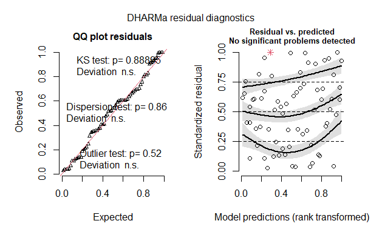

```r
# Obtain residuals
sim2 <- simulateResiduals(ysemp10, plot = T)
```

```
    DHARMa nonparametric dispersion test via sd of residuals fitted
    vs. simulated

data:  simulationOutput
dispersion = 1.0074, p-value = 0.864
alternative hypothesis: two.sided
```

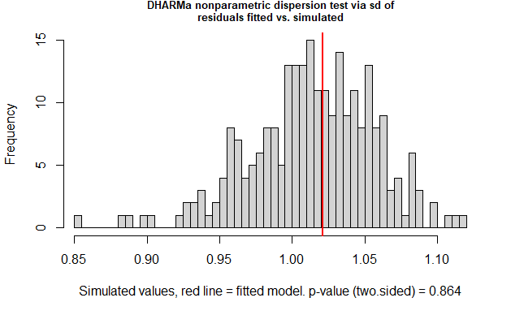

```r
# Check for under/over dispersion
testDispersion(sim2)
```

```
$uniformity
$uniformity$details
catPred: FALSE

    One-sample Kolmogorov-Smirnov test

data:  dd[x, ]
D = 0.12701, p-value = 0.9942
alternative hypothesis: two-sided

--------------------------------------------------------
catPred: TRUE

    One-sample Kolmogorov-Smirnov test

data:  dd[x, ]
D = 0.076358, p-value = 0.849
alternative hypothesis: two-sided


$uniformity$p.value
[1] 0.9942315 0.8489698

$uniformity$p.value.cor
[1] 1 1


$homogeneity
Levene's Test for Homogeneity of Variance (center = median)
      Df F value Pr(>F)
group  1  0.0375  0.847
      67
```

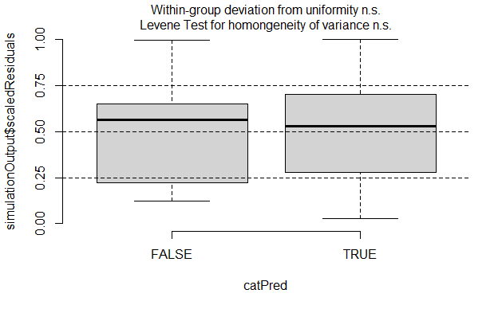

```r
# Check of residuals against predictors
testCategorical(sim2, catPred = y1semp$reg)
```

```
$uniformity
$uniformity$details
catPred: RT-PCR

    One-sample Kolmogorov-Smirnov test

data:  dd[x, ]
D = 0.080213, p-value = 0.7977
alternative hypothesis: two-sided

--------------------------------------------------------
catPred: Digital RT-PCR

    One-sample Kolmogorov-Smirnov test

data:  dd[x, ]
D = 0.32868, p-value = 0.7959
alternative hypothesis: two-sided

--------------------------------------------------------
catPred: TMA

    One-sample Kolmogorov-Smirnov test

data:  dd[x, ]
D = 0.38932, p-value = 0.3384
alternative hypothesis: two-sided


$uniformity$p.value
[1] 0.7977213 0.7958822 0.3383947

$uniformity$p.value.cor
[1] 1 1 1


$homogeneity
Levene's Test for Homogeneity of Variance (center = median)
      Df F value Pr(>F)
group  2  2.2044 0.1184
      66
```

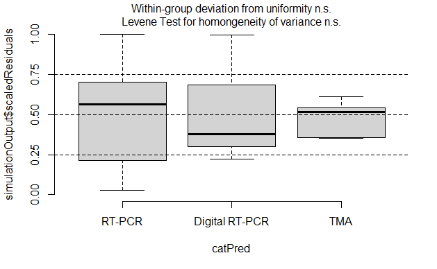

```r
testCategorical(sim2, catPred = y1semp$naat)
```

```
$uniformity
$uniformity$details
catPred: F

    One-sample Kolmogorov-Smirnov test

data:  dd[x, ]
D = 0.08809, p-value = 0.763
alternative hypothesis: two-sided

--------------------------------------------------------
catPred: T

    One-sample Kolmogorov-Smirnov test

data:  dd[x, ]
D = 0.11719, p-value = 0.9708
alternative hypothesis: two-sided


$uniformity$p.value
[1] 0.7630372 0.9708307

$uniformity$p.value.cor
[1] 1 1


$homogeneity
Levene's Test for Homogeneity of Variance (center = median)
      Df F value Pr(>F)
group  1  0.2222 0.6389
      67
```

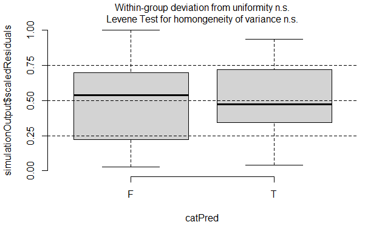

```r
testCategorical(sim2, catPred = y1semp$modified_protocol)
```

```
    Test for location of quantiles via qgam

data:  simulationOutput
p-value = 0.8595
alternative hypothesis: both
```

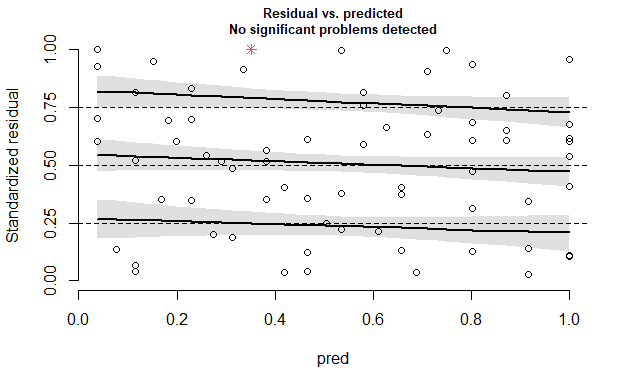

```r
# Check for homogeneity of variance over range of continuous variables
testQuantiles(sim2, predictor=y1semp$weak_posfold, plot=T)
```

```
    Test for location of quantiles via qgam

data:  simulationOutput
p-value = 0.8691
alternative hypothesis: both
```

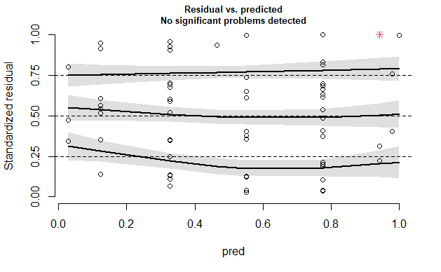

```r
testQuantiles(sim2, predictor=y1semp$log2p, plot=T)
```

```
    Test for location of quantiles via qgam

data:  simulationOutput
p-value = 0.8969
alternative hypothesis: both
```

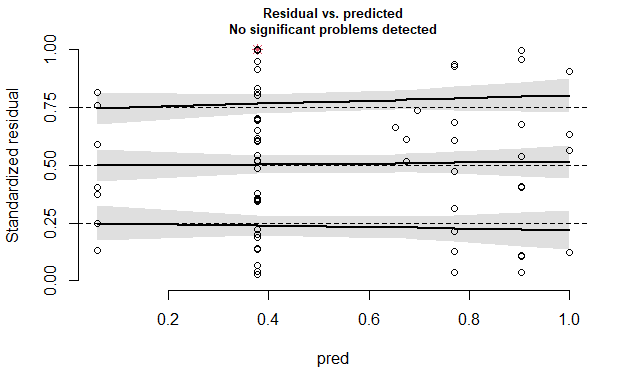

```r
testQuantiles(sim2, predictor=y1semp$modified_interpret, plot=T)
```

```r
# Check for homogeneity of variance between categories of factors
leveneTest(residuals(ysemp10) ~ y1semp$naat)
```

```
Levene's Test for Homogeneity of Variance (center = median)
      Df F value  Pr(>F)
group  2  2.5367 0.08682 .
      66
---
Signif. codes:  0 ‘***’ 0.001 ‘**’ 0.01 ‘*’ 0.05 ‘.’ 0.1 ‘ ’ 1
```

```r
leveneTest(residuals(ysemp10) ~ y1semp$sample)
```

```
Levene's Test for Homogeneity of Variance (center = median)
      Df F value Pr(>F)
group  1  0.0694 0.7931
      67
```

```r
leveneTest(residuals(ysemp10) ~ y1semp$modified_protocol)
```

```
Levene's Test for Homogeneity of Variance (center = median)
      Df F value Pr(>F)
group  1  0.0078   0.93
      67
```

```r
leveneTest(residuals(ysemp10) ~ y1semp$reg)
```

```
Levene's Test for Homogeneity of Variance (center = median)
      Df F value Pr(>F)
group  1  0.5492 0.4612
      67
```

```r
# Check for multi-colinearity by VIF
car::vif(ysemp10)
```

```
                           GVIF Df GVIF^(1/(2*Df))
naat                   2.299104  2        1.231373
log2p                  1.482947  1        1.217763
sample                 2.876524  1        1.696032
modified_protocol      2.631426  1        1.622167
bs(weak_posfold)       5.824591  3        1.341357
bs(modified_interpret) 7.930425  3        1.412156
reg                    2.132356  1        1.460259
```

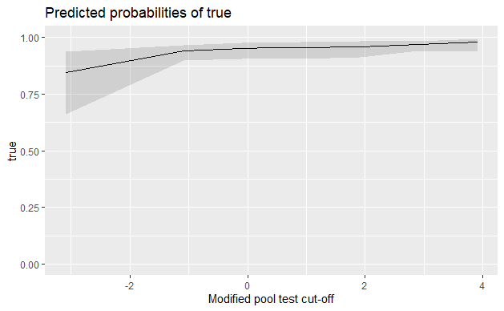

```r
plot_model(ysemp10, type = "eff", terms ="modified_interpret [all]")+ ylim (0,1)
```

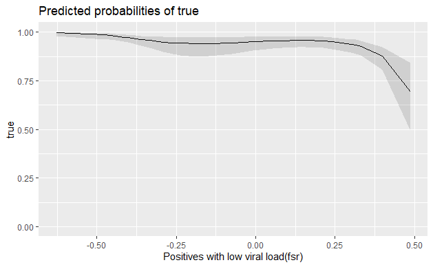

```r
plot_model(ysemp10, type = "eff", terms ="weak_posfold [all]")+ ylim (0,1)
```

Observations:

### 6.2.6 Summarising block-wise metaregression

#### Summary table

```r
#### Summarising metaregression (a) results
ysemp9_table <- tab_model (ysemp2, ysemp7,ysemp9,
                           show.p=FALSE, collapse.ci = TRUE,  show.reflvl = TRUE,
  pred.labels=c("Intercept","Weak positives (fsqroot)", "NAAT: digital PCR","NAAT: TMA", "log 2 of pool size","Sample type: saliva","Modified test protocol", "Modified pool test cut-off", "Regulatory approval: yes"),
  dv.labels=c("(A) Intercept only","(B) Block 1 and 2","(C) Block 3"))
```

[output not shown]

#### Summary of importance of covariates (MAY TAKE TIME TO RUN)

```r
R2_9m <- partR2(ysemp9, data = y1semp, R2_type = "marginal", nboot = 10)
```

[output not shown]

```r
R2_9m
```

```
R2 (marginal) and 95% CI for the full model:
```

| R2 | CI_lower | CI_upper | nboot | ndf |
| --- | --- | --- | --- | --- |
| 0.0999 | 0.0652 | 0.3286 | 10 | 9 |

```
----------

Part (semi-partial) R2:
[1] "No partitions selected."
```

```r
R2_9parts <- partR2(ysemp9, data = y1semp, partvars = c("reg", "naat","modified_interpret","modified_protocol","sample","log2p","weak_posfold"), R2_type= "marginal", nboot=10)
```

[output not shown]

```r
summary(R2_9parts)
```

```
R2 (marginal) and 95% CI for the full model:
```

| R2 | CI_lower | CI_upper | ndf |
| --- | --- | --- | --- |
| 0.0999 | 0.0803 | 0.4187 | 9 |

```
----------

Part (semi-partial) R2:
```

| Predictor(s) | R2 | CI_lower | CI_upper | ndf |
| --- | --- | --- | --- | --- |
| Model | 0.0999 | 0.0803 | 0.4187 | 9 |
| reg | 0.0086 | 0.0000 | 0.3567 | 8 |
| naat | 0.0307 | 0.0155 | 0.3718 | 7 |
| modified_interpret | 0.0079 | 0.0000 | 0.3563 | 8 |
| modified_protocol | 0.0153 | 0.0011 | 0.3613 | 8 |
| sample | 0.0131 | 0.0000 | 0.3598 | 8 |
| log2p | 0.0209 | 0.0063 | 0.3651 | 8 |
| weak_posfold | 0.0540 | 0.0373 | 0.3876 | 8 |
| reg+naat | 0.0317 | 0.0165 | 0.3724 | 6 |
| reg+modified_interpret | 0.0170 | 0.0027 | 0.3624 | 7 |

[output cut: 118 more lines]

```
----------

Inclusive R2 (SC^2 * R2):
```

| Predictor | IR2 | CI_lower | CI_upper |
| --- | --- | --- | --- |
| naatDigital RT-PCR | 0.0016 | 0.0001 | 0.3262 |
| naatTMA | 0.0051 | 0.0011 | 0.0156 |
| log2p | 0.0089 | 0.0041 | 0.0129 |
| sampleSaliva | 0.0038 | 0.0003 | 0.0159 |
| modified_protocolT | 0.0024 | 0.0000 | 0.0170 |
| weak_posfold | 0.0349 | 0.0133 | 0.0499 |
| modified_interpret | 0.0004 | 0.0000 | 0.0074 |
| regTRUE | 0.0029 | 0.0003 | 0.0627 |

```
----------

Structure coefficients r(Yhat,x):
```

| Predictor | SC | CI_lower | CI_upper |
| --- | --- | --- | --- |
| naatDigital RT-PCR | 0.1260 | -0.0631 | 0.8971 |
| naatTMA | -0.2269 | -0.3082 | -0.0660 |
| log2p | -0.2992 | -0.3484 | 0.1688 |
| sampleSaliva | -0.1960 | -0.3231 | -0.0508 |
| modified_protocolT | 0.1566 | -0.1125 | 0.3604 |
| weak_posfold | -0.5908 | -0.7244 | -0.1801 |
| modified_interpret | 0.0624 | -0.1374 | 0.1783 |
| regTRUE | 0.1696 | -0.3927 | 0.2208 |

```
----------

Beta weights (standardised estimates)
```

| Predictor | BW | CI_lower | CI_upper |
| --- | --- | --- | --- |
| naatDigital RT-PCR | 3.1159 | 1.6867 | 15.0568 |
| naatTMA | -1.4956 | -2.0169 | -0.9783 |
| log2p | -0.5878 | -0.8139 | -0.4365 |
| sampleSaliva | -0.8850 | -1.5300 | -0.4497 |
| modified_protocolT | 1.2225 | 0.5083 | 1.9648 |
| weak_posfold | -0.9034 | -1.1105 | -0.8467 |
| modified_interpret | 0.4111 | 0.1580 | 0.6304 |
| regTRUE | 1.1869 | 0.7913 | 1.7627 |

```
----------

Parametric bootstrapping resulted in warnings or messages:
Check r2obj$boot_warnings and r2obj$boot_messages.
```

```r
alt <- R2_9parts$IR2
alt
```

| term | estimate | CI_lower | CI_upper |
| --- | --- | --- | --- |
| naatDigital RT-PCR | 0.0015853553 | 7.327518e-05 | 0.326225095 |
| naatTMA | 0.0051420463 | 1.052544e-03 | 0.015592315 |
| log2p | 0.0089426248 | 4.106400e-03 | 0.012910316 |
| sampleSaliva | 0.0038376404 | 2.892932e-04 | 0.015888515 |
| modified_protocolT | 0.0024497655 | 1.849503e-05 | 0.017020533 |
| weak_posfold | 0.0348544720 | 1.334358e-02 | 0.049898039 |
| modified_interpret | 0.0003894919 | 8.796371e-06 | 0.007422964 |
| regTRUE | 0.0028734006 | 2.709981e-04 | 0.062748910 |

```r
alt2<- gt(alt)
alt
```

| term | estimate | CI_lower | CI_upper |
| --- | --- | --- | --- |
| naatDigital RT-PCR | 0.0015853553 | 7.327518e-05 | 0.326225095 |
| naatTMA | 0.0051420463 | 1.052544e-03 | 0.015592315 |
| log2p | 0.0089426248 | 4.106400e-03 | 0.012910316 |
| sampleSaliva | 0.0038376404 | 2.892932e-04 | 0.015888515 |
| modified_protocolT | 0.0024497655 | 1.849503e-05 | 0.017020533 |
| weak_posfold | 0.0348544720 | 1.334358e-02 | 0.049898039 |
| modified_interpret | 0.0003894919 | 8.796371e-06 | 0.007422964 |
| regTRUE | 0.0028734006 | 2.709981e-04 | 0.062748910 |

#### Plots summarising sources of heterogeneity

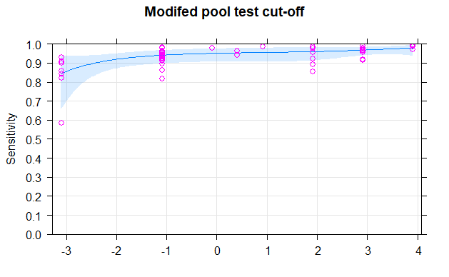

```r
# "EFFECTS" PACKAGE EXAMPLES

# Plot modified_intepret
plot1 <- plot(predictorEffects(ysemp10,~ modified_interpret, residuals=TRUE),
     main="Modifed pool test cut-off",
     axes = list(grid=TRUE,x=list(rug=TRUE, pool_size=list(lab ="Change in Cq cut-off(pool-standard)")), y=list(lab="Sensitivity", type="response",lim=c(0,1), ticks=list(at=c(0.0,0.1,0.2,0.3,0.4,0.5,0.6,0.7,0.8,0.9,1.0)))),
      partial.residuals=list(smooth=FALSE))
```

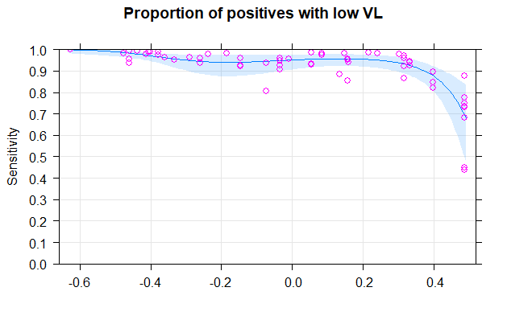

```r
# Plot weak_posfold
plot2 <-plot(predictorEffects(ysemp10,~ weak_posfold, residuals = TRUE),
     main="Proportion of positives with low VL",
     axes = list(grid=TRUE,x=list(rug=TRUE, pool_size=list(lab ="Proportion low VL")), y=list(lab="Sensitivity", type="response",lim=c(0,1), ticks=list(at=c(0.0,0.1,0.2,0.3,0.4,0.5,0.6,0.7,0.8,0.9,1.0)))),
     partial.residuals=list(smooth=FALSE))
```

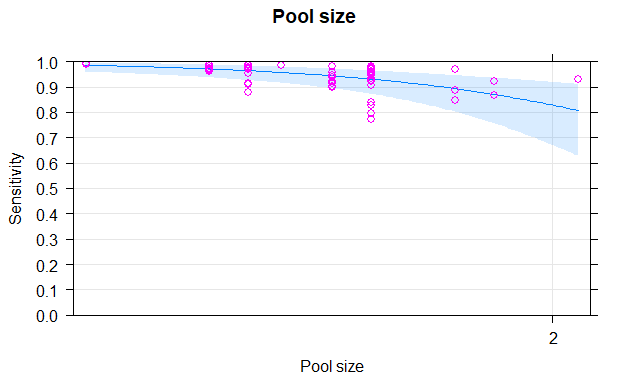

```r
# Plot log2p (pool size)
plot3 <- plot(predictorEffects(ysemp10,~log2p,residuals = TRUE),
     main="Pool size",
     axes = list(grid=TRUE,x=list(rug=TRUE, log2p=list(lab ="Pool size",
      ticks=list(at=c(2,4,6,8,10,12,14,16,18,20,22,24,26,28,30,32)))), y=list(lab="Sensitivity", type="response",lim=c(0,1), ticks=list(at=c(0.0,0.1,0.2,0.3,0.4,0.5,0.6,0.7,0.8,0.9,1.0)))),
     partial.residuals=list(smooth=FALSE))
```

```r
# "sjPlot" PACKAGE EXAMPLES

set_theme(base = theme_grey())
# Plot of Odds Ratios and Beta-coefficients (standardised coefficients)
por <- plot_model(ysemp9,sort.est=T, title = "Effects as Odds Ratios")
pbeta <- plot_model(ysemp9,sort.est=T, type = "std", title = "Beta-coefficients")
p <- ggplot(R2IR2, aes(x=reorder(term, estimate),y=estimate))
```

[output not shown]

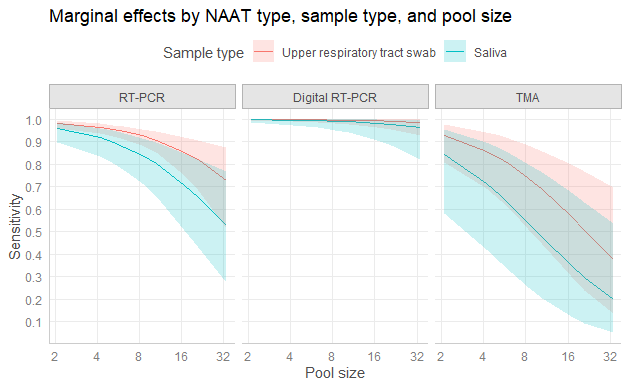

```r
# "ggeffects" PACKAGE EXAMPLES
theme_set(theme_ggeffects())
sampletype <- ggeffect(ysemp9, terms = c("log2p", "sample", "naat","weak_posfold [meansd]"))
sampletype <- sampletype %>% mutate(x = x+2.85895883542674)

sampletype2 <- ggemmeans(ysemp9, terms = c("log2p", "sample", "naat"), type="fe")
sampletype2 <- sampletype2 %>% mutate(x = x+2.85895883542674)

ggplot(sampletype2, aes(x = x, y = predicted, group = group, colour = group,
                       fill=group)) +
  geom_line()+
  geom_ribbon(aes(ymin = conf.low, ymax = conf.high, fill=group), linetype=0, alpha = .2) +
facet_wrap(~facet) +
  scale_x_continuous("Pool size", breaks=c(0,1,2,3,4,5), labels=function(x){2^x})+
  scale_y_continuous("Sensitivity", breaks=seq(0,1,0.1))+
  theme(legend.position="top")+
  theme(panel.grid.minor = element_blank())+
  labs(title="Marginal effects by NAAT type, sample type, and pool size",
  fill= "Sample type", colour = "Sample type")
```

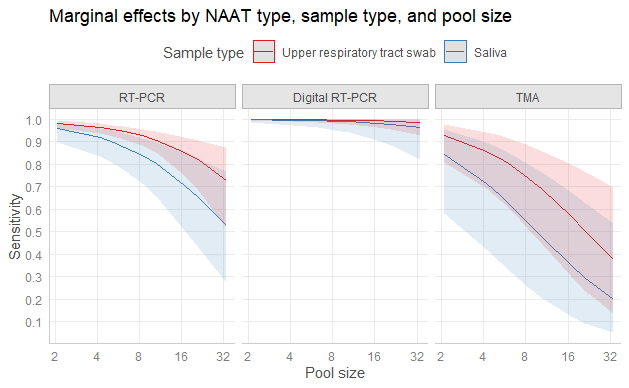

```r
plot(sampletype2, facet = TRUE)+
  labs(title="Marginal effects by NAAT type, sample type, and pool size",
  colour="Sample type", fill="Sample type")+
  scale_x_continuous("Pool size", breaks=c(0,1,2,3,4,5), labels=function(x){2^x})+
  scale_y_continuous("Sensitivity", breaks=seq(0,1,0.1))+
  theme(legend.position="top")+
  theme(panel.grid.minor = element_blank())
```

## 6.3 Metaregression with test evaluation random effects for sensitivity and fixed specificity

```r
Y1mp <- Y1mp %>% mutate(selog2p = log2p*sens)
Y1mp <- Y1mp %>% mutate(splog2p = log2p*spec)
Y1mp <- Y1mp %>% mutate(sereg = reg*sens)
Y1mp <- Y1mp %>% mutate(spreg = reg*spec)
Y1mp <- Y1mp %>% mutate(semodified_interpret = modified_interpret*sens)
Y1mp <- Y1mp %>% mutate(semod_protocol = modified_protocol*sens)
Y1mp <- Y1mp %>% mutate(seweak_pos = weak_pos*sens)
Y1mp <- Y1mp %>% mutate(spweak_pos = weak_pos*spec)
Y1mp <- Y1mp %>% mutate(senaat2 = naat2*sens)
Y1mp <- Y1mp %>% mutate(spnaat2 = naat2*spec)
Y1mp <- Y1mp %>% mutate(semultipos = multipos*sens)
Y1mp <- Y1mp %>% mutate(senaat2 = as.factor(senaat2))
Y1mp <- Y1mp %>% mutate(samp = if_else(sample=="Upper respiratory tract swab",1,0))
Y1mp <- Y1mp %>% mutate(sesamp=samp*sens)
Y1mp <- Y1mp %>% mutate(sesamp = as.factor(sesamp))
Y1mp$senaat2 <- fct_relevel(Y1mp$senaat2,"3","2","1","0")
Y1mp <- Y1mp %>% mutate(modprot = if_else(modified_protocol=="T",1,0))
Y1mp <- Y1mp %>% mutate(modprot=modprot*sens)
Y1mp <- Y1mp %>% mutate(semodprot = as.factor(modprot))
```

```r
ypartmp17 <- glmer (formula= cbind(true,n-true)~0+spec+sens+selog2p+seweak_pos+senaat2+sesamp+semodified_interpret+semodprot+sereg+(0+sens|testeval),
                 data = Y1mp,family=binomial, nAGQ=1,verbose=0,
                 control=glmerControl(optimizer="bobyqa",optCtrl=list
                                      (maxfun=2e5)))
ypartmp17_sum <- summary(ypartmp17)
ypartmp17_sum
ypartmp17_residuals <-simulateResiduals(ypartmp17, plot = T)
testDispersion(ypartmp17_residuals)
```

# 7. Test comparison

# 8. Sensitivity analysis

# 9. Bayesian implementation

```r
bayesian <- metadata %>% dplyr::select(eval_id, test_eval_id,
                                       cohort_id,t_p,f_n,f_p,t_n,disease_p, disease_n,
                                  pnaat, pool_size_gp,pool_size,naat,symptoms, sample, pool_type, sample_pool, log2p,modified_protocol,modified_interpret,
                                  reg, log2lod, num_target,index_assay)
bayesian <- bayesian %>% dplyr::rename(studynames = test_eval_id, TP = t_p, FN = f_n,
                                       FP = f_p, TN = t_n, n1 = disease_p, n2 = disease_n)
```

## 9.2 Summary estimates

### 9.2.1 Combinatorial

To obtain 95% CI by Bayesian inference, we used both default and user-defined values for the shape parameters ‘a’ and ‘b’ describing the prior beta distribution for binomial outcomes. User-defined values for ‘a’ and ‘b’ were identified from a priori estimates of 50th and 90th centiles of sensitivity (0.90 and 0.98) and specificity (0.970 and 0.999)

```r
sens_ab <- beta.select(list(x = 0.90, p = 0.5), list(x = 0.98, p = 0.9))
spec_ab <- beta.select(list(x = 0.97, p = 0.5), list(x = 0.999, p = 0.9))

# Sensitivity Using user-defined values
ycombaysian_sens <- binom.bayes(25,25,prior.shape1 = sens_ab[1], prior.shape2 = sens_ab[2])
print(ycombaysian_sens)
```

| method | x | n | shape1 | shape2 | mean | lower | upper | sig |
| --- | --- | --- | --- | --- | --- | --- | --- | --- |
| bayes | 25 | 25 | 33.25 | 1.19 | 0.9654472 | 0.9042977 | 1 | 0.05 |

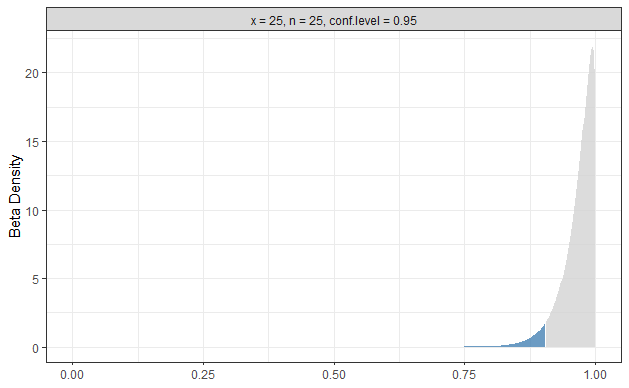

```r
binom.bayes.densityplot(ycombaysian_sens)
```

```r
# Sensitivity Using  defaults
ycombaysian_sens2 <- binom.bayes(25,25,prior.shape1 = 0.5, prior.shape2 =0.5)
print(ycombaysian_sens2)
```

| method | x | n | shape1 | shape2 | mean | lower | upper | sig |
| --- | --- | --- | --- | --- | --- | --- | --- | --- |
| bayes | 25 | 25 | 25.5 | 0.5 | 0.9807692 | 0.9267606 | 1 | 0.05 |

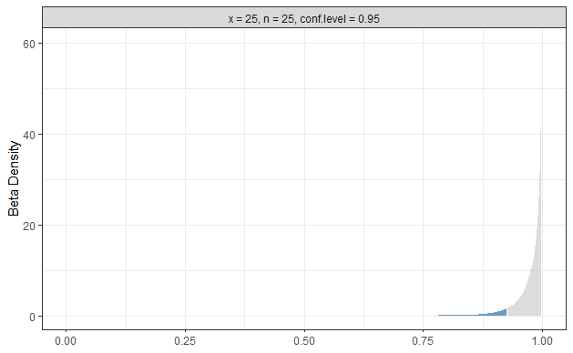

```r
binom.bayes.densityplot(ycombaysian_sens2)
```

```r
# Specificity using user-defined
ycombaysian_spec <- binom.bayes(1765,1766,prior.shape1 = spec_ab[1], prior.shape2 = spec_ab[2])
print(ycombaysian_spec)
```

| method | x | n | shape1 | shape2 | mean | lower | upper | sig |
| --- | --- | --- | --- | --- | --- | --- | --- | --- |
| bayes | 1765 | 1766 | 1772.47 | 1.49 | 0.9991601 | 0.9978075 | 0.9999992 | 0.05000001 |

[figure not shown]

```r
binom.bayes.densityplot(ycombaysian_spec)
```

```r
# Specificity using defaults
ycombaysian_spec2 <- binom.bayes(1765,1766,prior.shape1 = 0.5, prior.shape2 =0.5)
print(ycombaysian_spec2)
```

| method | x | n | shape1 | shape2 | mean | lower | upper | sig |
| --- | --- | --- | --- | --- | --- | --- | --- | --- |
| bayes | 1765 | 1766 | 1765.5 | 1.5 | 0.9991511 | 0.997789 | 0.9999991 | 0.05 |

[figure not shown]

```r
binom.bayes.densityplot(ycombaysian_spec2)
```